# Happiness and Corruption

Isai Mar

2022-11-23

# Happiness vs Corruption

I first tested if the data is normally distributed using a histogram:

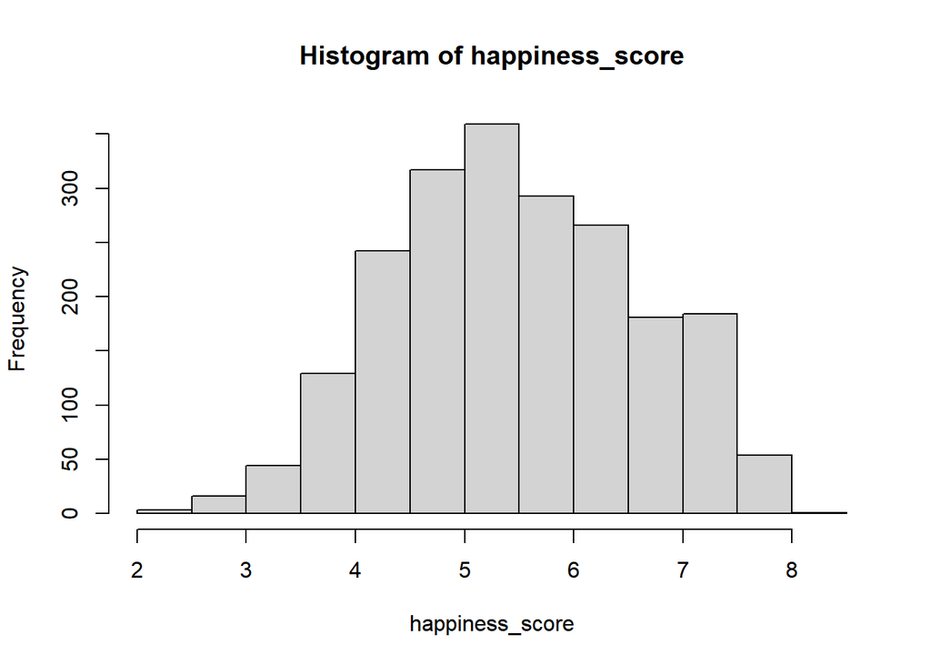

```r
#Testing the frequency of the scores in the Lifeladder and perceived corruption values.
happiness_score <- happiness$Life_Ladder
hist(happiness_score)
```

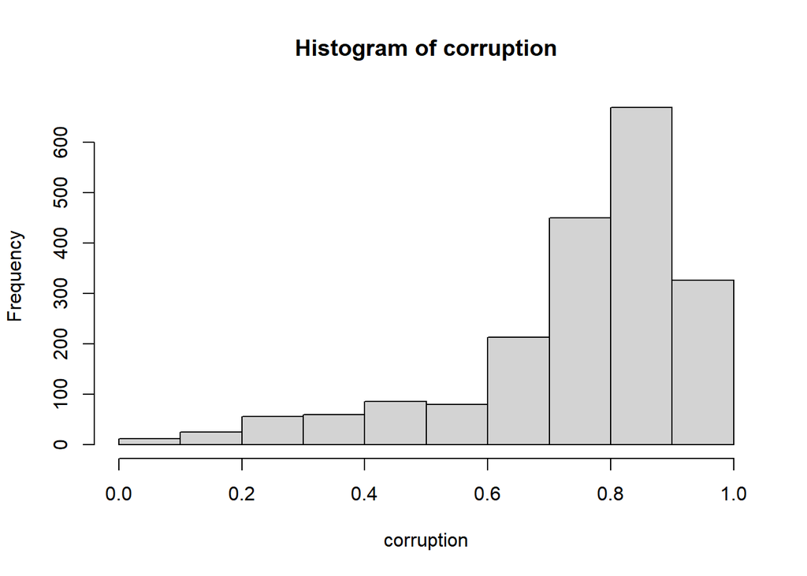

```r
corruption <- happiness$Perceptions_of_corruption
hist(corruption)
```

The histograms above reveal that the data is not normally distributed, so I decided to look at the date in two ways using an aov test and a linear regression.

## AOV test

My alpha level is 0.05.

```r
myaov <- aov(happiness_score~corruption,data=happiness)
summary(myaov)
```

```
##               Df Sum Sq Mean Sq F value Pr(>F)
## corruption     1  462.2   462.2   446.1 <2e-16 ***
## Residuals   1974 2045.1     1.0
## ---
## Signif. codes:  0 '***' 0.001 '**' 0.01 '*' 0.05 '.' 0.1 ' ' 1
## 113 observations deleted due to missingness
```

The results show that my p value is lower than my alpha which means that there is correlation between happiness and perceived corruption.

## Linear Regression

```r
mylm <- lm(happiness_score ~ corruption, data = happiness)
summary(mylm)
```

```
##
## Call:
## lm(formula = happiness_score ~ corruption, data = happiness)
##
## Residuals:
##     Min      1Q  Median      3Q     Max
## -3.8574 -0.7138  0.0959  0.8028  2.3493
##
## Coefficients:
##             Estimate Std. Error t value Pr(>|t|)
## (Intercept)  7.40176    0.09466   78.19   <2e-16 ***
## corruption  -2.59894    0.12305  -21.12   <2e-16 ***
## ---
## Signif. codes:  0 '***' 0.001 '**' 0.01 '*' 0.05 '.' 0.1 ' ' 1
##
## Residual standard error: 1.018 on 1974 degrees of freedom
##   (113 observations deleted due to missingness)
## Multiple R-squared:  0.1843, Adjusted R-squared:  0.1839
## F-statistic: 446.1 on 1 and 1974 DF,  p-value: < 2.2e-16
```

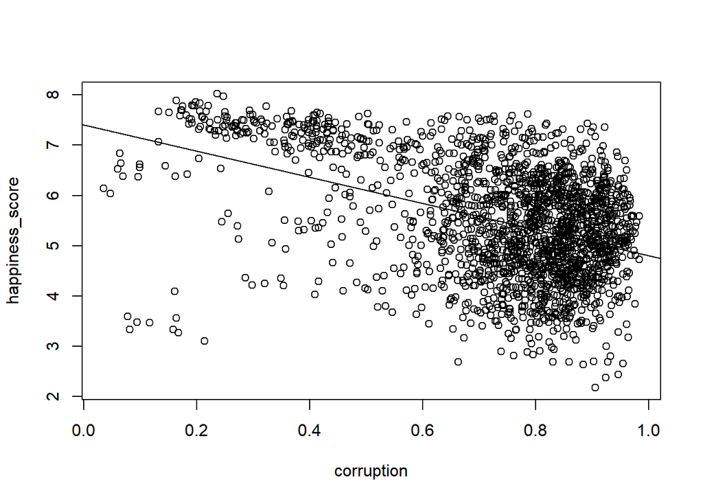

```r
plot(happiness_score ~ corruption, data = happiness)
abline(mylm)
```

As we can observe in the plot, the a higher perceive corruption score correlates with a lower happiness score.

## Conclusion

We can say that the corruption in a country does affect the happiness score of the people living in it. In further analysis we could test if the happiness score is correlated with other factors from the data set like freedom or GDP